# Data Analysis

Csaba Kertész

2021 01 09

# Income gap in Australia

The dataset was downloaded from data.gov.au. It contains data about income in different professions for both genders, published in 2008. In the following analysis I’m trying to explore the best and worst paying occupations for men and women, the wage gap between them, the possible association between yearly income, number of people in the same field and gender.

```r
#importing dataset
wages <- read.csv("https://raw.githubusercontent.com/rfordatascience/tidytuesday/master/data/2018/2018-04-23/week4_australian_salary.csv")
wages_tb <- as_tibble(wages)


#checking for missing values
sapply(wages_tb,function(x) sum(is.na(x)))
```

```
##                      X            gender_rank             occupation
##                      0                      0                      0
##                 gender            individuals average_taxable_income
##                      0                      0                      0
```

```r
#basic descriptives and plots
glimpse(wages_tb)
```

```
## Rows: 2,197
## Columns: 6
## $ X                      <int> 1, 2, 3, 4, 5, 6, 7, 8, 9, 10, 11, 12, 13, 1...
## $ gender_rank            <int> 795, 881, 699, 828, 641, 760, 200, 136, 157,...
## $ occupation             <chr> "Abattoir process worker; Meat process worke...
## $ gender                 <chr> "Female", "Male", "Female", "Male", "Female"...
## $ individuals            <int> 5961, 17241, 1386, 636, 1878, 903, 78380, 77...
## $ average_taxable_income <int> 36359, 40954, 40926, 44077, 43545, 47833, 71...
```

```r
describe(wages_tb)
```

```
##                        vars    n     mean       sd median  trimmed      mad
## X                         1 2197  1099.00   634.36   1099  1099.00   813.95
## gender_rank               2 2197   549.76   317.21    550   549.75   407.71
## occupation*               3 2197   552.67   318.75    553   552.67   409.20
## gender*                   4 2197     1.50     0.50      2     1.50     0.00
## individuals               5 2197  4683.71 14591.93    798  1722.33  1082.30
## average_taxable_income    6 2197 65678.16 51171.45  53850 56813.33 25638.60
##                          min    max  range  skew kurtosis      se
## X                          1   2197   2196  0.00    -1.20   13.53
## gender_rank                1   1104   1103  0.00    -1.20    6.77
## occupation*                1   1105   1104  0.00    -1.20    6.80
## gender*                    1      2      1 -0.01    -2.00    0.01
## individuals                3 293738 293735  8.58   109.47  311.31
## average_taxable_income 13307 577674 564367  4.28    25.34 1091.72
```

```r
summary(wages_tb)
```

```
##        X         gender_rank      occupation           gender
##  Min.   :   1   Min.   :   1.0   Length:2197        Length:2197
##  1st Qu.: 550   1st Qu.: 275.0   Class :character   Class :character
##  Median :1099   Median : 550.0   Mode  :character   Mode  :character
##  Mean   :1099   Mean   : 549.8
##  3rd Qu.:1648   3rd Qu.: 824.0
##  Max.   :2197   Max.   :1104.0
##   individuals     average_taxable_income
##  Min.   :     3   Min.   : 13307
##  1st Qu.:   209   1st Qu.: 38909
##  Median :   798   Median : 53850
##  Mean   :  4684   Mean   : 65678
##  3rd Qu.:  2960   3rd Qu.: 74441
##  Max.   :293738   Max.   :577674
```

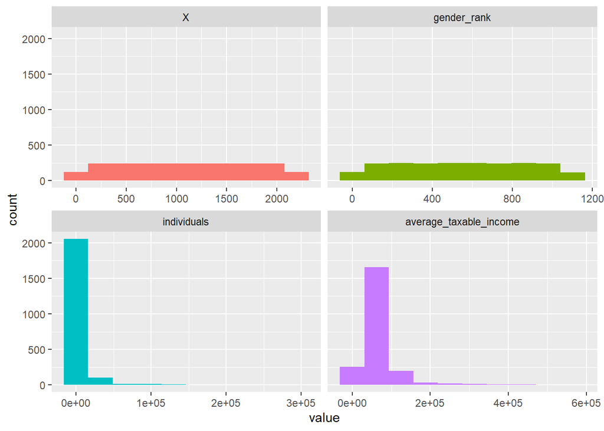

```r
plot_num(wages_tb)
```

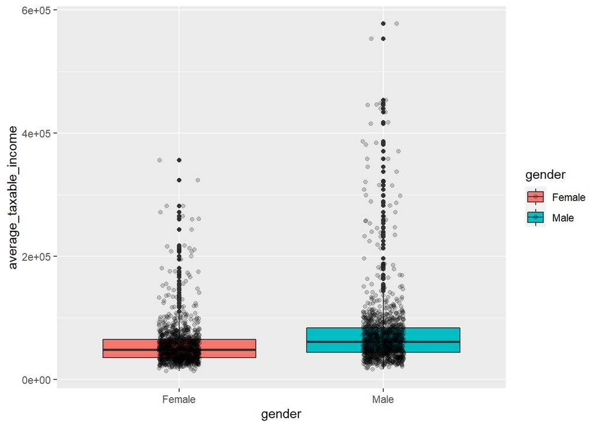

```r
wages_tb %>%
  ggplot(aes(x=gender, y=average_taxable_income, fill = gender)) +
  geom_boxplot() + geom_jitter(width=0.1,alpha=0.2)
```

```r
#adding income range variable
wages_tb <- wages_tb %>%
mutate(income_rg = ifelse(wages_tb$average_taxable_income<summary(wages_tb$average_taxable_income)[2], "Low income", ifelse(wages_tb$average_taxable_income>summary(wages_tb$average_taxable_income)[5], "High income", "Average income")))


#summarizing variables by gender
describeBy(wages_tb, wages_tb$gender)
```

```
##
##  Descriptive statistics by group
## group: Female
##                        vars    n     mean       sd median  trimmed      mad
## X                         1 1093  1098.22   633.71   1099  1098.32   812.46
## gender_rank               2 1093   547.00   315.67    547   547.00   404.75
## occupation*               3 1093   547.00   315.67    547   547.00   404.75
## gender*                   4 1093     1.00     0.00      1     1.00     0.00
## individuals               5 1093  4497.58 16407.87    502  1245.51   690.89
## average_taxable_income    6 1093 56109.10 35284.11  48511 50316.44 21159.67
## income_rg*                7 1093     1.80     0.90      1     1.76     0.00
##                          min    max  range skew kurtosis      se
## X                          1   2196   2195 0.00    -1.20   19.17
## gender_rank                1   1093   1092 0.00    -1.20    9.55
## occupation*                1   1093   1092 0.00    -1.20    9.55
## gender*                    1      1      0  NaN      NaN    0.00
## individuals                3 293738 293735 9.20   118.95  496.30
## average_taxable_income 13307 355844 342537 3.47    17.64 1067.26
## income_rg*                 1      3      2 0.39    -1.64    0.03
## ------------------------------------------------------------
## group: Male
##                        vars    n     mean       sd  median  trimmed      mad
## X                         1 1104  1099.77   635.29  1099.0  1099.67   816.91
## gender_rank               2 1104   552.50   318.84   552.5   552.50   409.20
## occupation*               3 1104   552.50   318.84   552.5   552.50   409.20
## gender*                   4 1104     1.00     0.00     1.0     1.00     0.00
## individuals               5 1104  4867.99 12542.59  1206.0  2217.62  1508.55
## average_taxable_income    6 1104 75151.86 61645.55 61591.5 63801.14 28548.20
## income_rg*                7 1104     1.70     0.75     2.0     1.62     1.48
##                          min    max  range skew kurtosis      se
## X                          2   2197   2195 0.00    -1.21   19.12
## gender_rank                1   1104   1103 0.00    -1.20    9.60
## occupation*                1   1104   1103 0.00    -1.20    9.60
## gender*                    1      1      0  NaN      NaN    0.00
## individuals                3 143209 143206 6.52    54.24  377.49
## average_taxable_income 16490 577674 561184 3.92    19.39 1855.31
## income_rg*                 1      3      2 0.57    -1.05    0.02
```

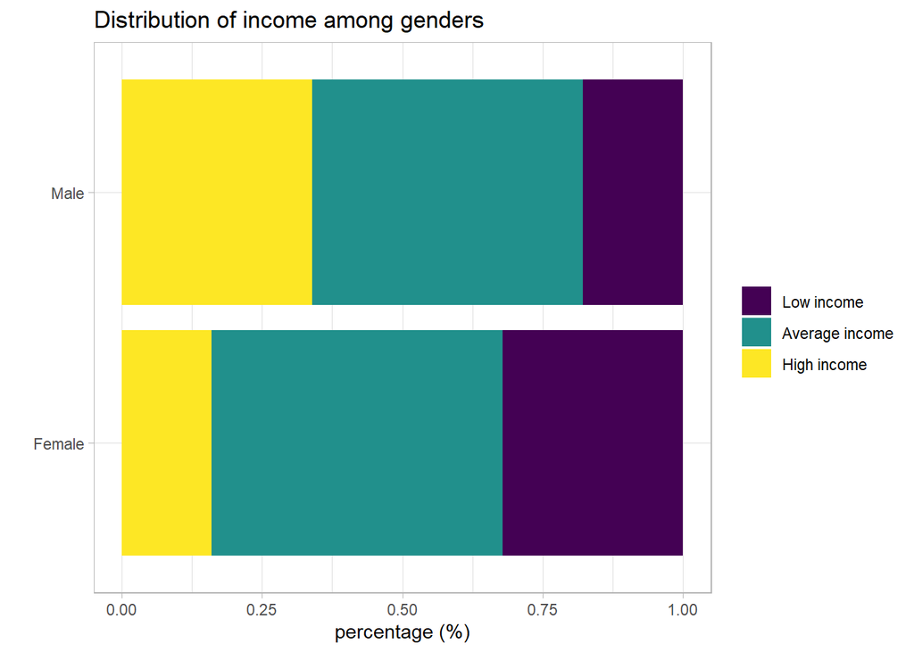

```r
#plot 1 - Distribution of income among male and female workers
wages_tb%>%
  mutate(income_rg = fct_relevel(income_rg,
            "Low income", "Average income", "High income")) %>%
ggplot(aes(x = gender, fill = income_rg)) +
    geom_bar(position = "fill") +
    scale_x_discrete(name = "") +
  scale_fill_viridis_d()+
    ylab(label="percentage (%)")+
    labs(fill = "")+
    theme_light() +
    coord_flip()+
    ggtitle("Distribution of income among genders")
```

Missing values, outliers, basic descriptives

There were no missing values in the dataset. Two outliers were identified in the “average taxable income” col. and were decided to be kept for this part of the analysis. The mean yearly taxable income in Australia was 65.678 (AUS), with a minimum of 13.307 and a maximum of 577.674. Exploring income by gender, I found that men altogether earned more. Mean income was 75.152/56.109, with a minimum 16.490/13.307 and maximum of 577.674/355.844.  
Looking at plot 1, we see that while similar proportion of men and women work in average income jobs, a larger percentage of men work in the high income range, while a higher proportion of women have low income professions.

```r
#filtering male vs female occupations in order of income
wages_order_male <- wages_tb %>%
      filter(gender == "Male") %>%
      arrange(desc(average_taxable_income)) %>%
      select(occupation, `Male Average Taxable Income` = average_taxable_income)

wages_order_male <- wages_order_male %>%
  rename(male_income = 2)

wages_order_female <- wages_tb %>%
      filter(gender == "Female") %>%
      arrange(desc(average_taxable_income)) %>%
      select(occupation, `Female Average Taxable Income` = average_taxable_income)

wages_order_female <- wages_order_female %>%
  rename(female_income = 2)


#pairing by same occupation, sorted by male income
occ_by_male  <- wages_order_male %>%
      left_join(., wages_order_female , by = "occupation") %>%
      arrange(desc(male_income))

#adding income range variable
occ_by_male <- occ_by_male %>%
  mutate(income_rg = ifelse(occ_by_male$male_income<summary(occ_by_male$male_income)[2], "Low income", ifelse(occ_by_male$male_income>summary(occ_by_male$male_income)[5], "High income", "Average income")))

#calculating relative income gap
occ_by_male <-  occ_by_male %>%
  mutate(gap = (male_income - female_income)/male_income)

occ_by_male <- occ_by_male %>%
  mutate(gap_percent = gap * 100)

occ_by_male %>%
  summary()
```

```
##   occupation         male_income     female_income     income_rg
##  Length:1104        Min.   : 16490   Min.   : 13307   Length:1104
##  Class :character   1st Qu.: 44054   1st Qu.: 34935   Class :character
##  Mode  :character   Median : 61592   Median : 48544   Mode  :character
##                     Mean   : 75152   Mean   : 56125
##                     3rd Qu.: 83518   3rd Qu.: 64575
##                     Max.   :577674   Max.   :355844
##                                      NA's   :12
##       gap           gap_percent
##  Min.   :-2.3310   Min.   :-233.10
##  1st Qu.: 0.1210   1st Qu.:  12.10
##  Median : 0.2008   Median :  20.08
##  Mean   : 0.1974   Mean   :  19.74
##  3rd Qu.: 0.2831   3rd Qu.:  28.31
##  Max.   : 0.8340   Max.   :  83.40
##  NA's   :12        NA's   :12
```

```r
female_adv <-  occ_by_male %>%
  filter(female_income > male_income)

female_adv %>%
  summary()
```

```
##   occupation         male_income     female_income     income_rg
##  Length:81          Min.   : 18100   Min.   : 20434   Length:81
##  Class :character   1st Qu.: 27431   1st Qu.: 28766   Class :character
##  Mode  :character   Median : 33344   Median : 36813   Mode  :character
##                     Mean   : 44333   Mean   : 50285
##                     3rd Qu.: 47746   3rd Qu.: 54397
##                     Max.   :264830   Max.   :281600
##       gap            gap_percent
##  Min.   :-2.33101   Min.   :-233.101
##  1st Qu.:-0.16131   1st Qu.: -16.131
##  Median :-0.07268   Median :  -7.268
##  Mean   :-0.14704   Mean   : -14.704
##  3rd Qu.:-0.03281   3rd Qu.:  -3.281
##  Max.   :-0.00170   Max.   :  -0.170
```

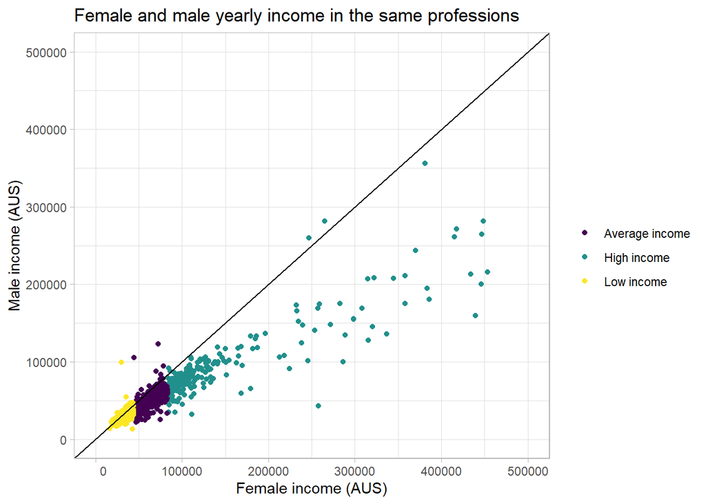

```r
#plot2 - Comparing female and male income in the same professions
occ_by_male%>%
  ggplot(aes(x = male_income , y = female_income, color=income_rg)) +
  geom_point() +
  scale_y_continuous(limits = c(0, 500000),
                     name = "Male income (AUS)", labels = function(x) format(x, scientific = FALSE))+
  scale_x_continuous(limits = c(0, 500000),
                     name = "Female income (AUS)",labels = function(x) format(x, scientific = FALSE))+
    theme_light() +
    geom_abline()+
    scale_color_viridis_d(name = "")+
    ggtitle("Female and male yearly income in the same professions")
```

The GAP

When we compare the income of men and women in the same professions, we see that men earn 19.74% more in average. The maximum relative wage gap is 83.4% (for cricketers) in favor of men. Interestingly we found that there is an extreme relative difference (233.1% for mountaineers), in which case there is a female advantage.

Looking at plot2, we see that there are very few occupations (81, which is only 7,3%) in which women earn more, most of which are in the “low income” range (56, 69%).

```r
 #identifying outliers in gap variable
out <- occ_by_male %>%
  arrange(gap_percent)


#removing 5 rows containing outliers
occ_by_male <-  occ_by_male[-c(1032), ]
occ_by_male <-  occ_by_male[-c(821), ]
occ_by_male <-  occ_by_male[-c(406), ]
occ_by_male <-  occ_by_male[-c(961), ]


#checking normality for variables - all 3 variables differ from normal distribution
shapiro.test(occ_by_male$male_income)
```

```
##
##  Shapiro-Wilk normality test
##
## data:  occ_by_male$male_income
## W = 0.6003, p-value < 2.2e-16
```

```r
shapiro.test(occ_by_male$female_income)
```

```
##
##  Shapiro-Wilk normality test
##
## data:  occ_by_male$female_income
## W = 0.69097, p-value < 2.2e-16
```

```r
shapiro.test(occ_by_male$gap)
```

```
##
##  Shapiro-Wilk normality test
##
## data:  occ_by_male$gap
## W = 0.9818, p-value = 1.989e-10
```

```r
cor.test(occ_by_male$male_income, occ_by_male$gap, method = c("s"))
```

```
##
##  Spearman's rank correlation rho
##
## data:  occ_by_male$male_income and occ_by_male$gap
## S = 107784881, p-value < 2.2e-16
## alternative hypothesis: true rho is not equal to 0
## sample estimates:
##       rho
## 0.4978624
```

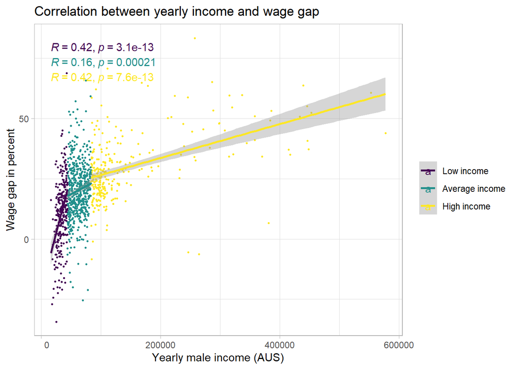

```r
#plot3 - Correlation between yearly income and wage gap in 3 income categories
occ_by_male %>%
   mutate(income_rg = fct_relevel(income_rg,
            "Low income", "Average income", "High income")) %>%
ggplot(aes(x=male_income, y=gap_percent, color = income_rg)) +
  theme_light() +
  geom_point(size =0.5) +
scale_y_continuous(name = "Wage gap in percent", labels = function(x) format(x, scientific = FALSE))+
  scale_x_continuous(name = "Yearly male income (AUS)",labels = function(x) format(x, scientific = FALSE))+
  scale_color_viridis_d(name = "")+
  geom_smooth(method=lm)+
  stat_cor(method = "spearman")+
  ggtitle("Correlation between yearly income and wage gap")
```

The correlation between wage gap and income

Our hypothesis was that the relative wage gap widens as income grows. To test our hypothesis we calculated Spearman correlation for the two variables and found that there is in fact a positive association (rho =0.4978624 , p = 2.2e-16) between them. The higher the average income, the greater the gap becomes.

Plot3 also shows that the correlation between income and the wage gap persists in each income category with a weak association in the average income range, and moderate (R = 0.42) in the “high” and “low” categories.

```r
#BUILDING MODELS to predict income with gender and individuals variables

#testing normality of target variable - normality assumption not met
shapiro.test(wages_tb$average_taxable_income)
```

```
##
##  Shapiro-Wilk normality test
##
## data:  wages_tb$average_taxable_income
## W = 0.60671, p-value < 2.2e-16
```

```r
#normalizing target variable with z-transformation
normalize = function(x){
  return(((x - min(x, na.rm = TRUE))/(max(x, na.rm = TRUE))))
}


wages_tb <- wages_tb %>%
  mutate(income_norm = normalize(average_taxable_income))


#Building first linear model
model_1 <- lm(income_norm ~ gender + individuals, data = wages_tb)
summary(model_1)
```

```
##
## Call:
## lm(formula = income_norm ~ gender + individuals, data = wages_tb)
##
## Residuals:
##      Min       1Q   Median       3Q      Max
## -0.10117 -0.04355 -0.01713  0.01452  0.86920
##
## Coefficients:
##               Estimate Std. Error t value Pr(>|t|)
## (Intercept)  7.477e-02  2.694e-03  27.748   <2e-16 ***
## genderMale   3.302e-02  3.715e-03   8.889   <2e-16 ***
## individuals -1.496e-07  1.273e-07  -1.175     0.24
## ---
## Signif. codes:  0 '***' 0.001 '**' 0.01 '*' 0.05 '.' 0.1 ' ' 1
##
## Residual standard error: 0.08705 on 2194 degrees of freedom
## Multiple R-squared:  0.03524,    Adjusted R-squared:  0.03436
## F-statistic: 40.07 on 2 and 2194 DF,  p-value: < 2.2e-16
```

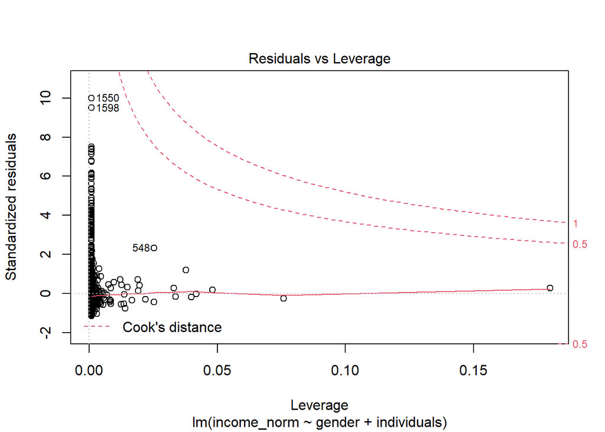

```r
#model diagnostics and outliers
model_1 %>%
  plot(5)
```

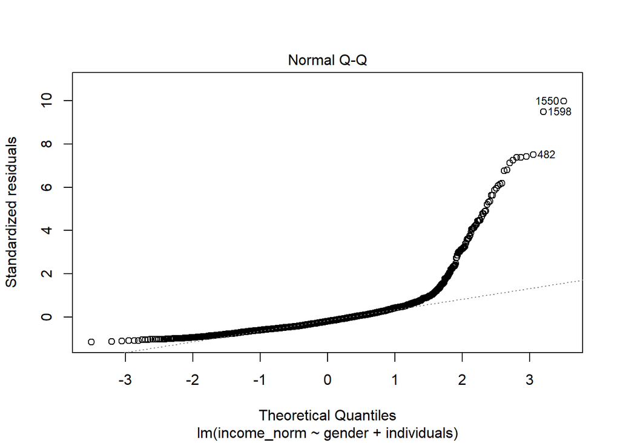

```r
model_1 %>%
  plot(2)
```

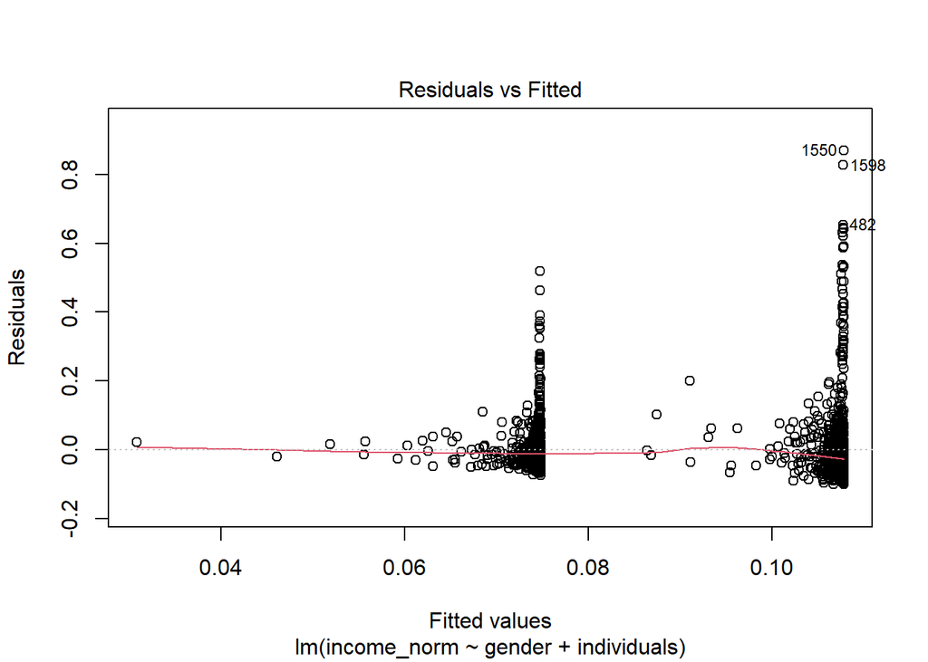

```r
model_1 %>%
  plot(1)
```

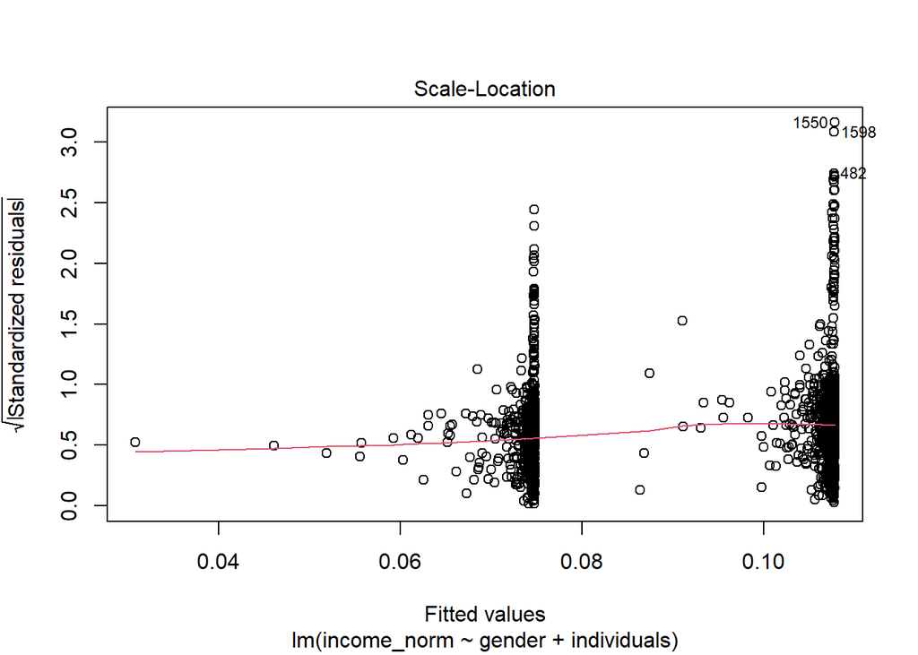

```r
model_1 %>%
  plot(3)
```

```r
model_1 %>%
  vif()
```

```
##      gender individuals
##    1.000161    1.000161
```

```r
#removing outliers
wages_tb<- wages_tb[-c(1550, 1598, 482, 548, 1682, 1202),]

#Building second model
model_2 <- lm(income_norm ~ gender, data = wages_tb)
summary(model_2)
```

```
##
## Call:
## lm(formula = income_norm ~ gender, data = wages_tb)
##
## Residuals:
##      Min       1Q   Median       3Q      Max
## -0.09935 -0.04262 -0.01614  0.01514  0.64855
##
## Coefficients:
##             Estimate Std. Error t value Pr(>|t|)
## (Intercept) 0.074094   0.002480  29.874   <2e-16 ***
## genderMale  0.030764   0.003504   8.781   <2e-16 ***
## ---
## Signif. codes:  0 '***' 0.001 '**' 0.01 '*' 0.05 '.' 0.1 ' ' 1
##
## Residual standard error: 0.082 on 2189 degrees of freedom
## Multiple R-squared:  0.03402,    Adjusted R-squared:  0.03358
## F-statistic:  77.1 on 1 and 2189 DF,  p-value: < 2.2e-16
```

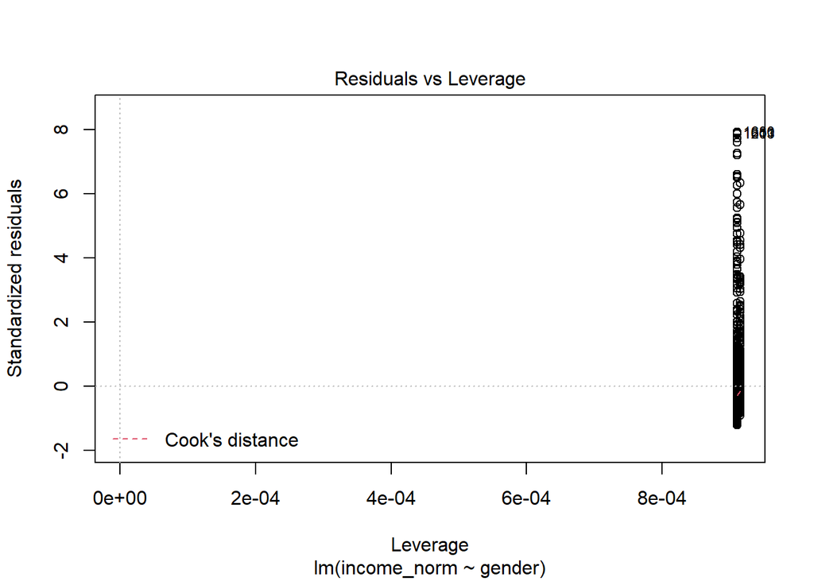

```r
#model diagnostics and outliers
model_2 %>%
  plot(5)
```

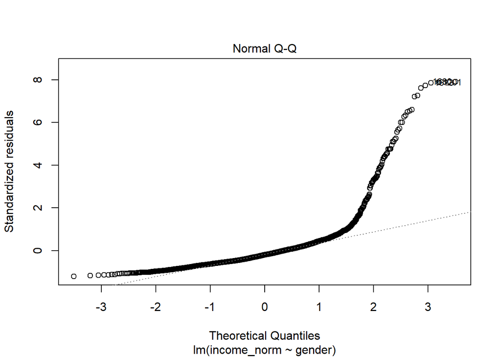

```r
model_2 %>%
  plot(2)
```

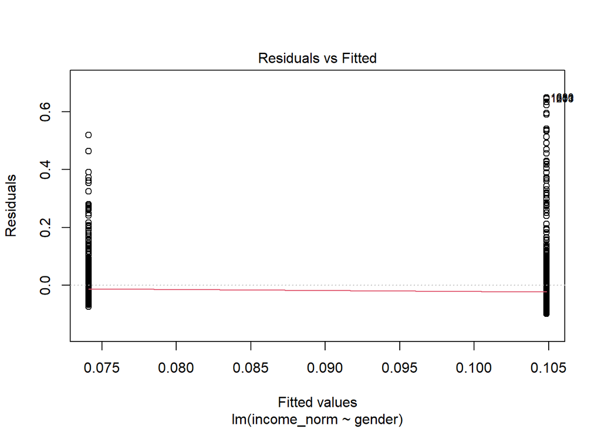

```r
model_2 %>%
  plot(1)
```

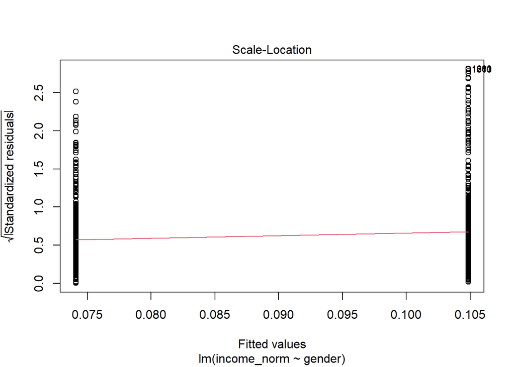

```r
model_2 %>%
  plot(3)
```

```r
#removing outliers
wages_tb <- wages_tb[-c(1609),]

model_1 <- lm(income_norm ~ gender + individuals, data = wages_tb)
model_2 <- lm(income_norm ~ gender, data = wages_tb)

model_2 %>%
lm.beta()
```

```
##
## Call:
## lm(formula = income_norm ~ gender, data = wages_tb)
##
## Standardized Coefficients::
## (Intercept)  genderMale
##   0.0000000   0.1844279
```

```r
model_2 %>%
coef()
```

```
## (Intercept)  genderMale
##  0.07409387  0.03076640
```

```r
model_2 %>%
confint(level = 0.95)
```

```
##                  2.5 %     97.5 %
## (Intercept) 0.06922889 0.07895886
## genderMale  0.02389254 0.03764025
```

```r
anova(model_1, model_2)
```

```
## Analysis of Variance Table
##
## Model 1: income_norm ~ gender + individuals
## Model 2: income_norm ~ gender
##   Res.Df    RSS Df Sum of Sq    F Pr(>F)
## 1   2187 14.704
## 2   2188 14.718 -1 -0.013985 2.08 0.1494
```

Building a model for predicting income

ANOVA shows that the two models do not differ significantly.

SUMMARY The analysis shows that although gender plays an important role, it is not sufficient in itself to predict income. We hypothesize that the field in which an individual is working has a robust effect on wages. Unfortunately the dataset doesn’t contain a categorical variable for grouping the many kinds of occupations. We created a subset dataset with a “field” variable containing 6 values that we could extract from the “occupations” variable using string matching. This second analysis is only an attempt to get a sense of how robust an effect the field of work has on income (by common sense I hypothesize that a strong one).

```r
#identifying some fields among occupations for later analyses by string match
scientist=wages_tb[grep("scien",wages_tb$occupation),]
engineer=wages_tb[grep("engineer",wages_tb$occupation),]
worker=wages_tb[grep("worker",wages_tb$occupation),]
nurse=wages_tb[grep("nurse",wages_tb$occupation),]
surgeon=wages_tb[grep("surgeon",wages_tb$occupation),]
cook=wages_tb[grep("cook",wages_tb$occupation),]

scientific <- scientist %>%
  mutate(field = "science")

engineer <- engineer %>%
  mutate(field = "engineer")

worker <- worker %>%
  mutate(field = "worker")

nurse <- nurse %>%
  mutate(field = "nurse")

surgeon <- surgeon %>%
  mutate(field = "surgeon")

cook <- cook %>%
  mutate(field = "cook")

#creating subset table with "field" variable
wages_tb_field <-  rbind(cook, worker, surgeon, nurse, scientific, engineer)


#descriptives by field
describeBy(wages_tb_field, wages_tb_field$field)
```

```
##
##  Descriptive statistics by group
## group: cook
##                        vars  n     mean      sd   median  trimmed     mad
## X                         1 10   413.10  343.18   305.50   372.00  219.42
## gender_rank               2 10  1005.60   88.29  1035.50  1014.12   63.01
## occupation*               3 10     3.00    1.49     3.00     3.00    1.48
## gender*                   4 10     1.50    0.53     1.50     1.50    0.74
## individuals               5 10  4174.40 4898.10  2565.50  3365.75 3249.12
## average_taxable_income    6 10 28114.70 6768.34 27947.00 27372.00 3564.91
## income_rg*                7 10     1.90    0.32     2.00     2.00    0.00
## income_norm               8 10     0.03    0.01     0.03     0.02    0.01
## field*                    9 10     1.00    0.00     1.00     1.00    0.00
##                             min      max    range  skew kurtosis      se
## X                        131.00  1024.00   893.00  0.93    -0.84  108.52
## gender_rank              841.00  1102.00   261.00 -0.81    -0.90   27.92
## occupation*                1.00     5.00     4.00  0.00    -1.62    0.47
## gender*                    1.00     2.00     1.00  0.00    -2.19    0.17
## individuals              132.00 14686.00 14554.00  1.02    -0.49 1548.92
## average_taxable_income 18988.00 43183.00 24195.00  0.76    -0.01 2140.34
## income_rg*                 1.00     2.00     1.00 -2.28     3.57    0.10
## income_norm                0.01     0.05     0.04  0.76    -0.01    0.00
## field*                     1.00     1.00     0.00   NaN      NaN    0.00
## ------------------------------------------------------------
## group: engineer
##                        vars   n     mean       sd   median  trimmed      mad
## X                         1 102   946.13   625.87   929.50   918.94   727.96
## gender_rank               2 102   257.13   191.02   193.50   223.65   127.50
## occupation*               3 102    26.00    14.79    26.00    26.00    19.27
## gender*                   4 102     1.50     0.50     1.50     1.50     0.74
## individuals               5 102  2718.36  5479.26   631.00  1444.74   879.92
## average_taxable_income    6 102 83586.89 27024.17 80664.50 81636.72 23909.15
## income_rg*                7 102     1.71     0.52     2.00     1.72     0.00
## income_norm               8 102     0.12     0.05     0.12     0.12     0.04
## field*                    9 102     1.00     0.00     1.00     1.00     0.00
##                             min      max     range  skew kurtosis      se
## X                         37.00   2101.0   2064.00  0.22    -1.00   61.97
## gender_rank               38.00    956.0    918.00  1.82     3.44   18.91
## occupation*                1.00     51.0     50.00  0.00    -1.24    1.46
## gender*                    1.00      2.0      1.00  0.00    -2.02    0.05
```

[output cut: 88 more lines]

```
## individuals               5 120  8128.80 28725.23  1871.00  3171.02  2487.06
## average_taxable_income    6 120 44635.38 19326.53 40604.00 41425.44 11205.49
## income_rg*                7 120     1.98     0.96     2.00     1.97     1.48
## income_norm               8 120     0.05     0.03     0.05     0.05     0.02
## field*                    9 120     1.00     0.00     1.00     1.00     0.00
##                             min       max     range  skew kurtosis      se
## X                          1.00   2195.00   2194.00  0.19    -1.16   59.70
## gender_rank               55.00   1093.00   1038.00 -0.92     0.13   23.75
## occupation*                1.00     60.00     59.00  0.00    -1.23    1.59
## gender*                    1.00      2.00      1.00  0.00    -2.02    0.05
## individuals               29.00 293738.00 293709.00  8.44    79.09 2622.24
## average_taxable_income 19704.00 109866.00  90162.00  1.62     2.52 1764.26
## income_rg*                 1.00      3.00      2.00  0.05    -1.91    0.09
## income_norm                0.01      0.17      0.16  1.62     2.52    0.00
## field*                     1.00      1.00      0.00   NaN      NaN    0.00
```

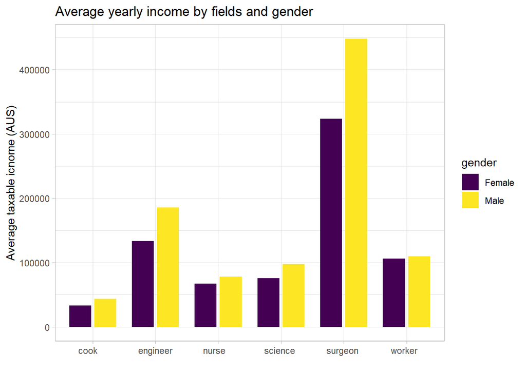

```r
#plot4 - The income gap in different fields
wages_tb_field %>%
ggplot(aes(x = field, y = average_taxable_income, fill = gender)) + geom_col(position = position_dodge(width = 0.8), width = 0.7)+
  scale_fill_viridis_d() +
   theme(axis.text.x = element_text(size = 10, angle = 45)) +
  scale_y_continuous(name = "Average taxable icnome (AUS)", labels = function(x) format(x, scientific = FALSE))+
  scale_x_discrete(name = "",labels = function(x) format(x, scientific = FALSE))+
  theme_light() +
  ggtitle("Average yearly income by fields and gender")
```

```r
#Building linear model for the subset dataset
model_3 <- lm(income_norm ~ gender + field, data = wages_tb_field)
summary(model_3)
```

```
##
## Call:
## lm(formula = income_norm ~ gender + field, data = wages_tb_field)
##
## Residuals:
##      Min       1Q   Median       3Q      Max
## -0.38644 -0.02127 -0.00015  0.01563  0.30033
##
## Coefficients:
##               Estimate Std. Error t value Pr(>|t|)
## (Intercept)   0.007980   0.018065   0.442  0.65900
## genderMale    0.035307   0.006388   5.527 7.03e-08 ***
## fieldengineer 0.096027   0.018632   5.154 4.61e-07 ***
## fieldnurse    0.043667   0.019831   2.202  0.02842 *
## fieldscience  0.068292   0.021163   3.227  0.00139 **
## fieldsurgeon  0.409785   0.023652  17.326  < 2e-16 ***
## fieldworker   0.028599   0.018507   1.545  0.12331
## ---
## Signif. codes:  0 '***' 0.001 '**' 0.01 '*' 0.05 '.' 0.1 ' ' 1
##
## Residual standard error: 0.05623 on 303 degrees of freedom
## Multiple R-squared:  0.6693, Adjusted R-squared:  0.6627
## F-statistic: 102.2 on 6 and 303 DF,  p-value: < 2.2e-16
```

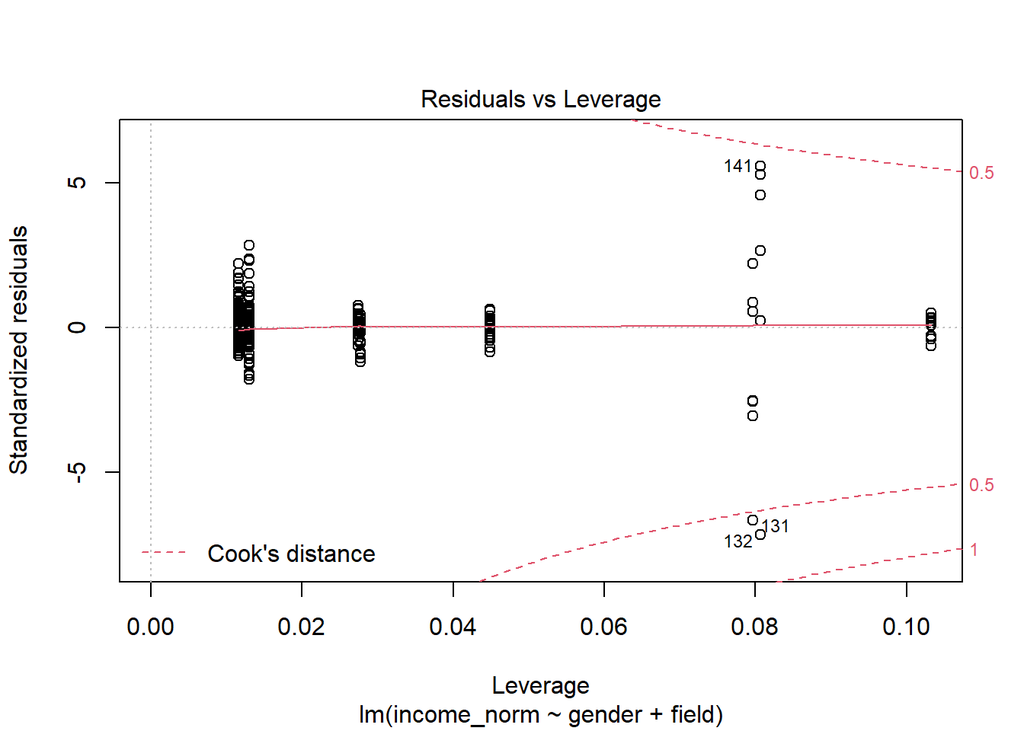

```r
#Model diagnostics and outliers
model_3 %>%
  plot(5)
```

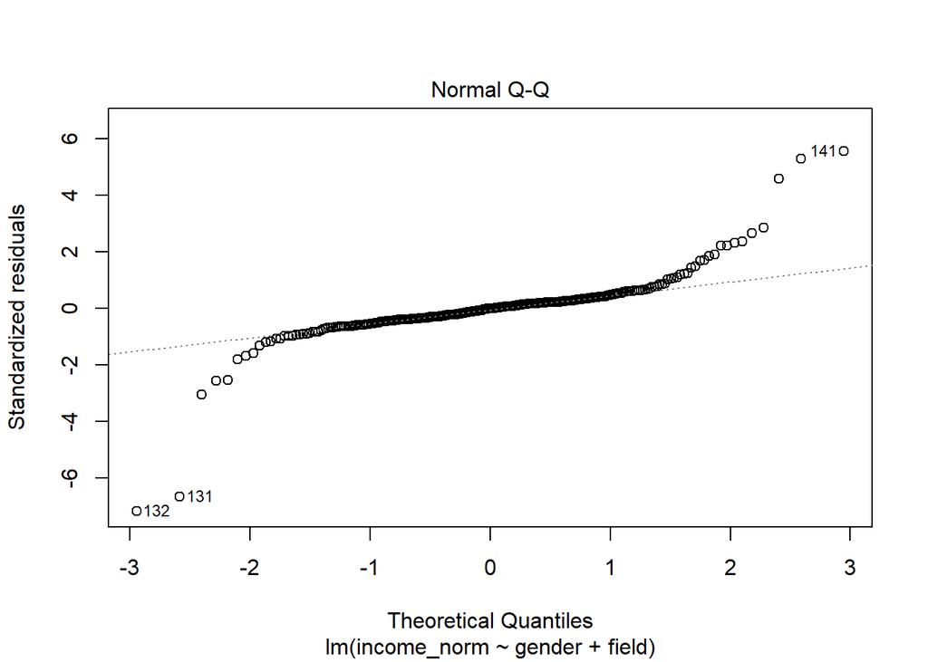

```r
model_3 %>%
  plot(2)
```

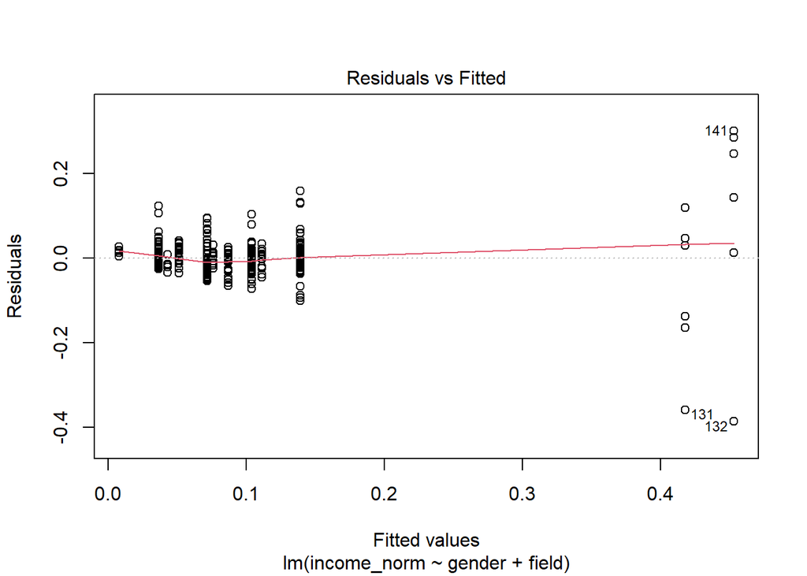

```r
model_3 %>%
  plot(1)
```

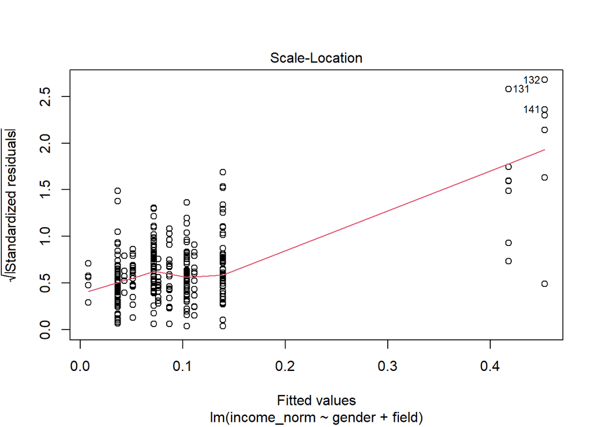

```r
model_3 %>%
  plot(3)
```

```r
#removing outliers
wages_tb_field <- wages_tb_field[-c(131, 132, 134, 135, 141),]

model_3 <- lm(income_norm ~ gender + field, data = wages_tb_field)
summary(model_3)
```

```
##
## Call:
## lm(formula = income_norm ~ gender + field, data = wages_tb_field)
##
## Residuals:
##       Min        1Q    Median        3Q       Max
## -0.188024 -0.021044 -0.000577  0.014516  0.263282
##
## Coefficients:
##               Estimate Std. Error t value Pr(>|t|)
## (Intercept)   0.008805   0.013814   0.637  0.52436
## genderMale    0.033656   0.004927   6.831 4.74e-11 ***
## fieldengineer 0.096027   0.014244   6.742 8.11e-11 ***
## fieldnurse    0.043647   0.015160   2.879  0.00428 **
## fieldscience  0.068292   0.016179   4.221 3.23e-05 ***
## fieldsurgeon  0.432254   0.020399  21.190  < 2e-16 ***
## fieldworker   0.028599   0.014148   2.021  0.04413 *
## ---
## Signif. codes:  0 '***' 0.001 '**' 0.01 '*' 0.05 '.' 0.1 ' ' 1
##
## Residual standard error: 0.04298 on 298 degrees of freedom
## Multiple R-squared:  0.7261, Adjusted R-squared:  0.7206
## F-statistic: 131.7 on 6 and 298 DF,  p-value: < 2.2e-16
```

```r
model_3 %>%
  vif()
```

```
##            GVIF Df GVIF^(1/(2*Df))
## gender 1.001625  1        1.000812
## field  1.001625  5        1.000162
```

```r
model_3 %>%
lm.beta()
```

```
##
## Call:
## lm(formula = income_norm ~ gender + field, data = wages_tb_field)
##
## Standardized Coefficients::
##   (Intercept)    genderMale fieldengineer    fieldnurse  fieldscience
##     0.0000000     0.2072745     0.5580473     0.1833920     0.2264961
##  fieldsurgeon   fieldworker
##     0.8509279     0.1720885
```

```r
model_3 %>%
coef()
```

```
##   (Intercept)    genderMale fieldengineer    fieldnurse  fieldscience
##   0.008805151   0.033656329   0.096026811   0.043647180   0.068292281
##  fieldsurgeon   fieldworker
##   0.432254132   0.028598613
```

```r
model_3 %>%
confint(level = 0.95)
```

```
##                       2.5 %     97.5 %
## (Intercept)   -0.0183808884 0.03599119
## genderMale     0.0239605555 0.04335210
## fieldengineer  0.0679958725 0.12405775
## fieldnurse     0.0138122323 0.07348213
## fieldscience   0.0364530509 0.10013151
## fieldsurgeon   0.3921103769 0.47239789
## fieldworker    0.0007560139 0.05644121
```

SUMMARY - subset dataset

The third, exploratory model included “gender” and “field” as variables to predict “income” After removing outliers the model met the normality and linearity assumption, but violated homoscedasticty. Multicollinearity was acceptable as VIF for both variables was under 5. This model accounted for 72% of variance of the “income” variable.

Exploring each variable’s contribution by their standard coefficients (beta), the “field” variable’s values showed strong influence. Variables in order of beta value were: surgeon - 0,85; engineer - 0,56; science - 0,23; gender (male) - 0,21; worker - 0,17.

CONCLUSION

All variables showed a significant contribution to the total variance, with “field” far overweighing “gender”. Plot4 also shows that the gap between male and female income widens in higher income fields, confirming the earlier conclusion drawn from the whole dataset.

As this was only an exploratory model with a fraction of the whole dataset, there can be no far reaching conclusions drawn from this last analysis, but the results stress the importance of the dataset be updated by a categorical variable for the different professions if we plan to build better models.